# Airbnb Data Visualization

Chawdhari,Khandalikar

## Loading Libraries

```r
library(ggplot2) # Plotting
library(plyr)    # Group by and pivoting type analysis
library(reshape2) # Change layout of dataframes
library(ggthemes)
library(dplyr)
```

## Load Cleaned Data for Listings and Calendar

```r
#Read Data from file
dflistings <- read.csv("Data//CleanedListings.csv")
dfCalendars <- read.csv("Data//CalendarCleaned.csv")

#Convert a few datatype values
dflistings$neighbourhood_cleansed <- as.factor(dflistings$neighbourhood_cleansed)
dflistings$Description_ClusterGroup <- as.factor(dflistings$Description_ClusterGroup)
dflistings$first_review <- as.Date(dflistings$first_review)
dflistings$last_review <- as.Date(dflistings$last_review)
dflistings$host_since <- as.Date(dflistings$host_since)
dfCalendars$available <- as.factor(dfCalendars$available)
dfCalendars$date <- as.Date(dfCalendars$date)
dfCalendars$year <- as.factor(dfCalendars$year)
dfCalendars$month <- as.factor(dfCalendars$month)

#Check the data strucure
str(dflistings)
```

```
## 'data.frame':    5206 obs. of  157 variables:
##  $ X                                         : int  0 1 2 3 4 5 6 7 8 9 ...
##  $ id                                        : int  13824783 16740225 18125245 8362570 789867 16701336 8148031 6713059 17620535 12581064 ...
##  $ name                                      : Factor w/ 5169 levels "","(01A) Apartment Steps From Chicago's Grant Park",..: 2083 2293 1692 2759 1624 3065 3930 3871 4395 1928 ...
##  $ host_id                                   : int  55020055 36722941 51669215 32837114 2782694 36722941 43018961 2441740 756599 23503681 ...
##  $ host_name                                 : Factor w/ 1790 levels "5 Star Resorts Plus",..: 1441 418 1679 683 284 418 1392 928 1356 589 ...
##  $ host_since                                : Date, format: "2016-01-17" "2015-06-25" ...
##  $ host_response_time                        : Factor w/ 5 levels "","a few days or more",..: 5 5 5 4 5 5 5 1 5 5 ...
##  $ host_response_rate                        : num  100 100 100 100 100 ...
##  $ host_is_superhost                         : int  1 0 0 1 0 0 0 0 0 1 ...
##  $ host_listings_count                       : int  1 3 1 1 1 3 1 1 1 2 ...
##  $ host_total_listings_count                 : int  1 3 1 1 1 3 1 1 1 2 ...
##  $ host_verifications                        : Factor w/ 229 levels "[]","['email', 'facebook', 'reviews', 'jumio']",..: 91 201 188 91 51 201 122 199 93 138 ...
##  $ host_identity_verified                    : int  1 1 1 1 1 1 1 1 1 1 ...
##  $ street                                    : Factor w/ 268 levels "Albany Park, Chicago, IL 60618, United States",..: 154 65 154 154 155 154 155 65 65 154 ...
```

[output cut: 86 more lines]

```r
str(dfCalendars)
```

```
## 'data.frame':    1900555 obs. of  8 variables:
##  $ X         : int  0 1 2 3 4 5 6 7 8 9 ...
##  $ listing_id: int  13824783 13824783 13824783 13824783 13824783 13824783 13824783 13824783 13824783 13824783 ...
##  $ date      : Date, format: "2018-02-23" "2018-02-22" ...
##  $ available : Factor w/ 2 levels "f","t": 1 1 1 1 1 1 1 1 1 1 ...
##  $ price     : num  0 0 0 0 0 0 0 0 0 0 ...
##  $ year      : Factor w/ 2 levels "2017","2018": 2 2 2 2 2 2 2 2 2 2 ...
##  $ month     : Factor w/ 12 levels "Apr","Aug","Dec",..: 4 4 4 4 4 4 4 4 4 4 ...
##  $ day       : int  23 22 21 20 19 18 17 16 15 14 ...
```

## General EDA

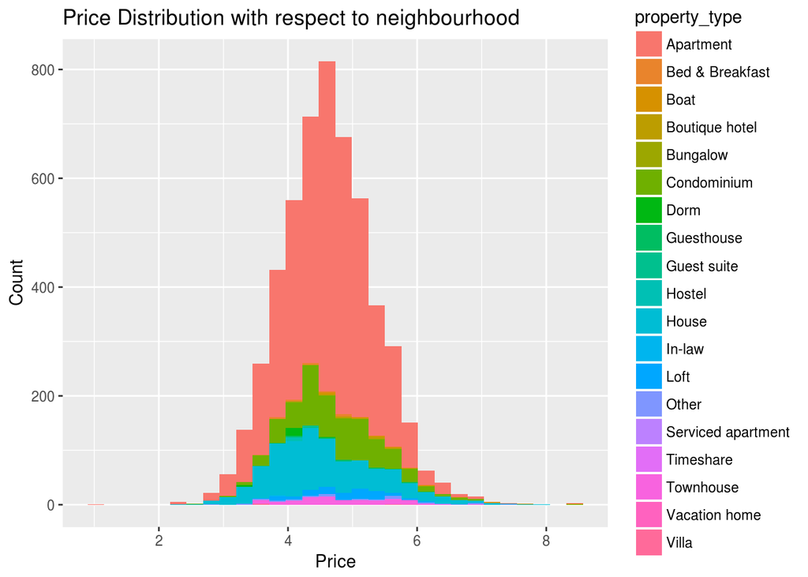

```r
#Price Distribution with respect to neighbourhood

ggplot(data = dflistings) +
  geom_histogram(mapping = aes(x= log(price),fill = property_type) ) +
    ggtitle("Price Distribution with respect to neighbourhood") +
      ylab("Count")+
        xlab("Price")
```

```r
summary(dflistings$price)
```

```
##    Min. 1st Qu.  Median    Mean 3rd Qu.    Max.
##     0.0    63.0    99.0   136.2   155.0  5000.0
```

**Description Cluster Group**

How does DescriptionClustergroup relates with Price and Reviews

we wanted to see if the cluster group really meant any difference with respect to price and reviews Looks like the clusters are actually different, 1.listings with higher number of reviews and lower price are clustered together

2.Listings with medium reviews and medium price

3.Listings with low reviews but higher price

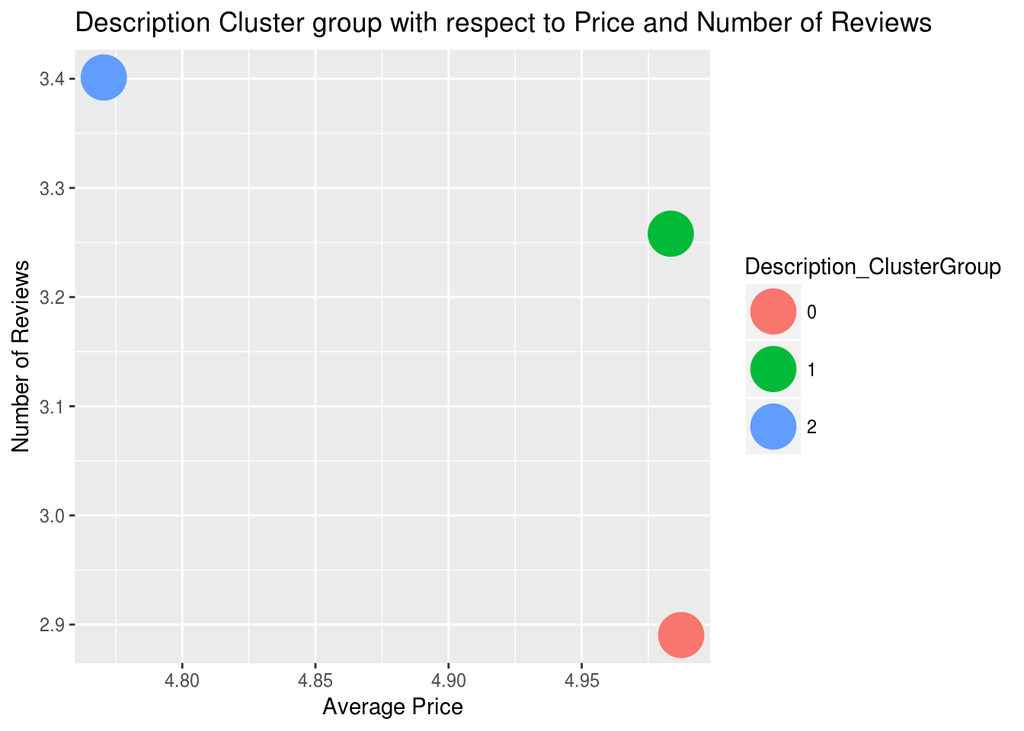

```r
tempdf<- dflistings %>%group_by(Description_ClusterGroup)%>%summarize(PriceAverage = mean(price),Reviews= mean(number_of_reviews))

ggplot(tempdf, aes(log(PriceAverage), log(as.integer(Reviews))  ,color = Description_ClusterGroup )) +
  geom_point(size = 10) +
  ggtitle("Description Cluster group with respect to Price and Number of Reviews") +
  xlab("Average Price") +
  ylab("Number of Reviews")
```

**Number of Listing by Property Type**

It can be clearly noticed that more than 60% of the listings are type ‘Apartment’ and thus dominates the listing on Airbnb followed by Condominium and Houses,with almost negible amount of other types! The possible reason would be that most of Hosts on Airbnb use listings as investments where the initial cost for property_type would be lower than other property type.

We replace all the other categories from Property type to others since,their presence would not provide any good insights about the data

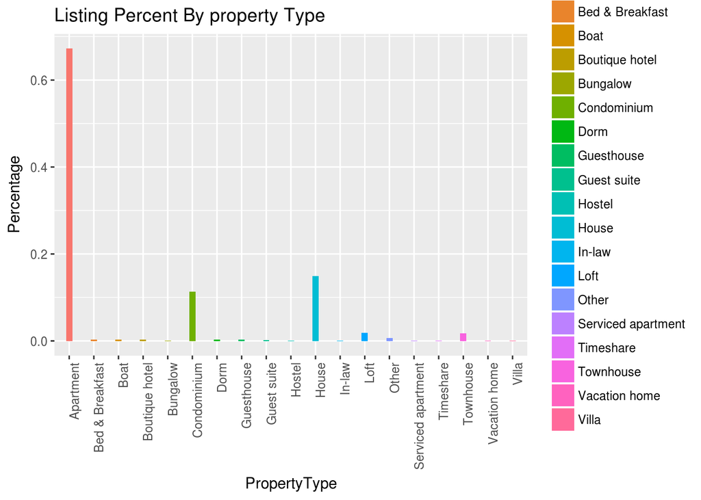

```r
ggplot(dflistings, aes(x = property_type, y = (..count..)/sum(..count..) ,fill = property_type )) +
geom_bar(width = 0.25) +
    theme(axis.text.x=element_text(angle=90,hjust=1)) +
    ggtitle("Listing Percent By property Type") +
    ylab("Percentage")+
      xlab("PropertyType")
```

```r
# Change the Property type for Listing to Others except for Apartments,Condominiums and Houses

dflistings$property_type <- as.character(dflistings$property_type)

dflistings$property_type<-ifelse (dflistings$property_type == 'Apartment' | dflistings$property_type == 'Condominium'  |  dflistings$property_type == 'House' , dflistings$property_type, "Others")

dflistings$property_type <- as.factor(dflistings$property_type)
```

**Number of Listing by Room Type**

A similar trend can be also seem with respect to the room type ,where Entire Home dominated the count and makes up for 60% of the total listings followed by private room and a very less amount of Shared rooms!

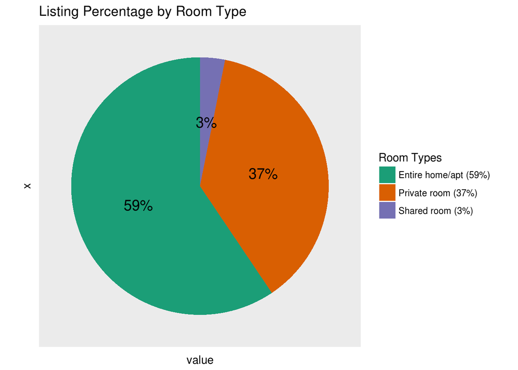

```r
room_types_counts <- table(dflistings$room_type)
room_types <- names(room_types_counts)
counts <- as.vector(room_types_counts)
percentages <- scales::percent(round(counts/sum(counts), 2))
room_types_percentages <- sprintf("%s (%s)", room_types, percentages)
room_types_counts_df <- data.frame(group = room_types, value = counts)

# Plot
pie <- ggplot(room_types_counts_df, aes(x = "", y = value, fill = room_types_percentages))+
  geom_bar(width = 1, stat = "identity")+
  coord_polar("y", start = 0)+
  scale_fill_brewer("Room Types", palette = "Dark2")+
  ggtitle("Listing Percentage by Room Type")+
  theme(axis.ticks = element_blank(), panel.grid = element_blank(), axis.text = element_blank())+
  geom_text(aes(label = percentages), size = 5, position = position_stack(vjust = 0.5))
pie
```

**Listings By Neighbourhood**

The listings seems to be pretty saturated with respect to neighbourhood,it seems that a few neighbourhoods like Westown,Lakeview have higher desity of listings while the others have very low or neiglible listing counts.

It would be interesting to see how this affect the price and income, since higher concentration on listings in a particular are could lead to more competition that woud lead to reduced price

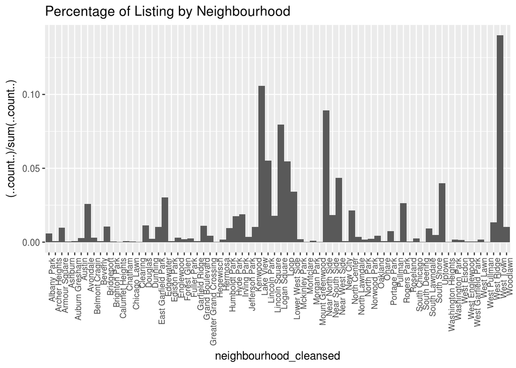

```r
ggplot(dflistings,aes(x=neighbourhood_cleansed,y = (..count..)/sum(..count..)))  +
  geom_bar(width = 1, position = position_dodge(width = 0.1)) + theme(axis.text.x = element_text(angle = 90, hjust = 1,size=8))+
  ggtitle("Percentage of Listing by Neighbourhood")
```

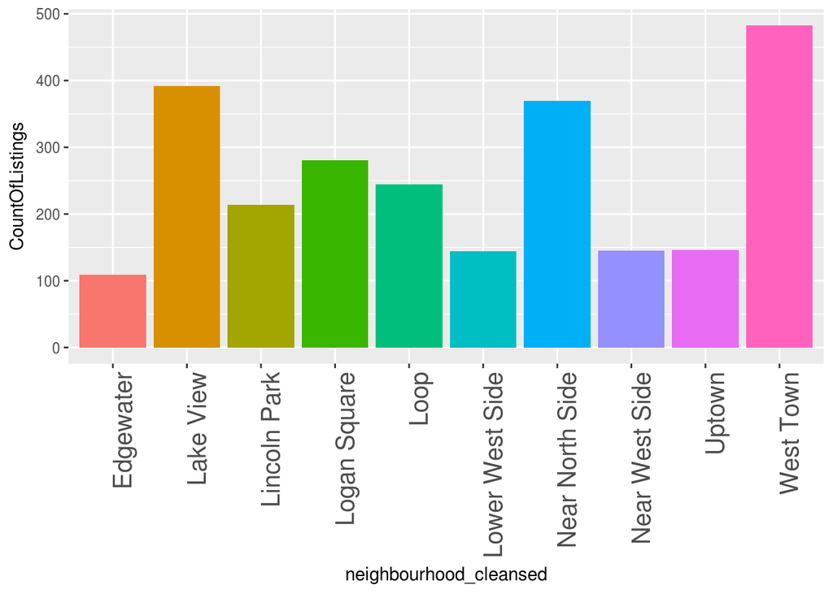

```r
# top 10 Neighbourhoods By Count
tempdfC <- dflistings %>% group_by(neighbourhood_cleansed,property_type) %>% summarize(CountOfListings = n())%>%
  arrange(desc(CountOfListings))%>% head(10)

tempdfP <- dflistings %>% group_by(neighbourhood_cleansed,property_type) %>% summarize(AveragePrice = mean(price))%>%
  arrange(desc(AveragePrice))%>% head(10)


ggplot(tempdfC,aes(x=neighbourhood_cleansed,y = CountOfListings ,fill = neighbourhood_cleansed))  +
  geom_bar(stat = 'identity',show.legend=F) + theme(axis.text.x = element_text(angle = 90, hjust = 1,size =15))
```

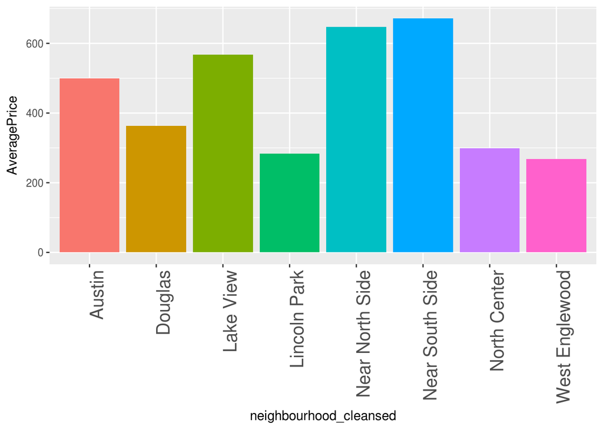

```r
ggplot(tempdfP,aes(x=neighbourhood_cleansed,y =  AveragePrice,fill = neighbourhood_cleansed))  +
  geom_bar(stat = 'identity',show.legend=F) + theme(axis.text.x = element_text(angle = 90, hjust = 1,size =15))
```

It can be seen that there are very few neigbourhood with higher Average Price and Higher listing Count, most of the neighbourhood lie in the bottom left part !!!

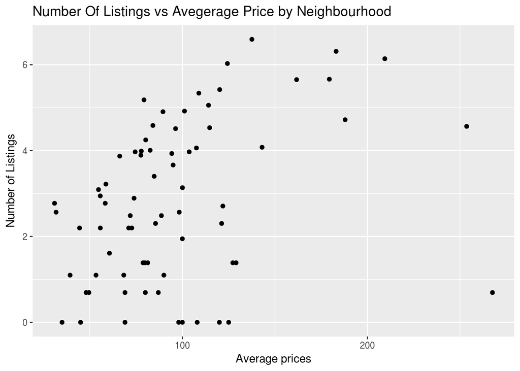

```r
tempdf = dflistings%>%
              group_by(neighbourhood_cleansed) %>% summarise(AvgPrice = mean(price), NumberofListing = n())


ggplot(data = tempdf, aes(x = AvgPrice, y = log(NumberofListing))) +
geom_point()+
  ggtitle("Number Of Listings vs Avegerage Price by Neighbourhood") +
  xlab("Average prices") +
  ylab("Number of Listings")
```

**Effect of Room Type and Property Type**

Through the Heat Map,it could be seem that we have higher number of Listings where the roomtype is EntireApt and the Property Type is Apartment While the average price remains high for Entire Home/Apt and goes on increasing from Condo to to other types that includes (Villas,Boats).

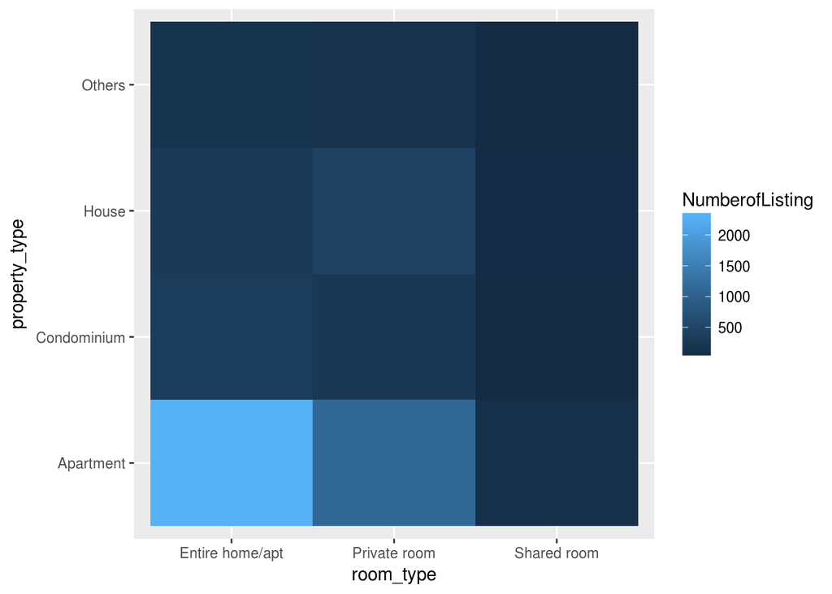

```r
roomProperty_DF = dflistings%>%
              group_by(room_type,property_type) %>% summarise(AvgPrice = mean(price), NumberofListing = n())

ggplot(data = roomProperty_DF, aes(x = room_type, y = property_type )) +
  geom_tile(aes(fill = NumberofListing ))
```

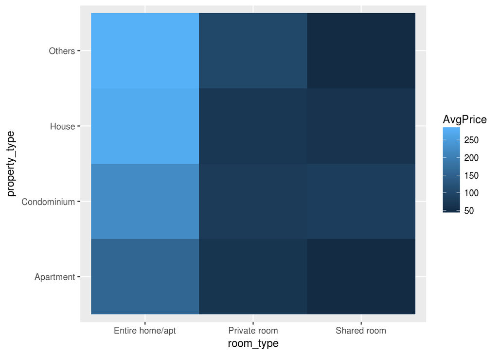

```r
ggplot(data = roomProperty_DF, aes(x = room_type, y = property_type )) +
  geom_tile(aes(fill = AvgPrice ))
```

**Correlation Between a few numeric variables and Price**

```r
cor(dflistings[,c(27,28,29,30,32)])
```

```
##              accommodates bathrooms  bedrooms      beds     price
## accommodates    1.0000000 0.4700603 0.7367851 0.8180493 0.4332237
## bathrooms       0.4700603 1.0000000 0.5439398 0.4892617 0.3700747
## bedrooms        0.7367851 0.5439398 1.0000000 0.7450092 0.3930253
## beds            0.8180493 0.4892617 0.7450092 1.0000000 0.3632175
## price           0.4332237 0.3700747 0.3930253 0.3632175 1.0000000
```

## Analysis by Host Related Data

**Number of Hosts Over the years**

It looks like the popularity of airbnb with hosts in Chicago kept increasing and reached a peak in year 2015,with some decrease in 2016 ,since we do not have complete data for year 2017 there is a huge drop for year 2017

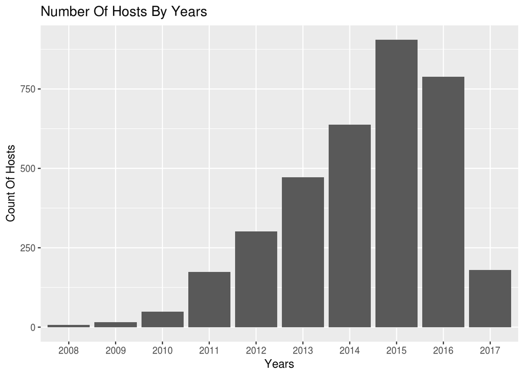

```r
tempdf <- dflistings %>% group_by(as.numeric(format(dflistings$host_since,"%Y")))

tempHostCount<- dflistings %>% group_by(Year= as.numeric(format(dflistings$host_since,"%Y"))) %>% summarise(NumberOfHosts = length(unique(host_id)))


ggplot(tempHostCount, aes( as.factor(tempHostCount$Year),NumberOfHosts)) + geom_bar(stat= 'identity') +
  ggtitle("Number Of Hosts By Years") +
  ylab("Count Of Hosts")+
  xlab("Years")
```

There is not really a noticeable trend for what month of the year the hosts join,although the number in consistently good for June and July !!!

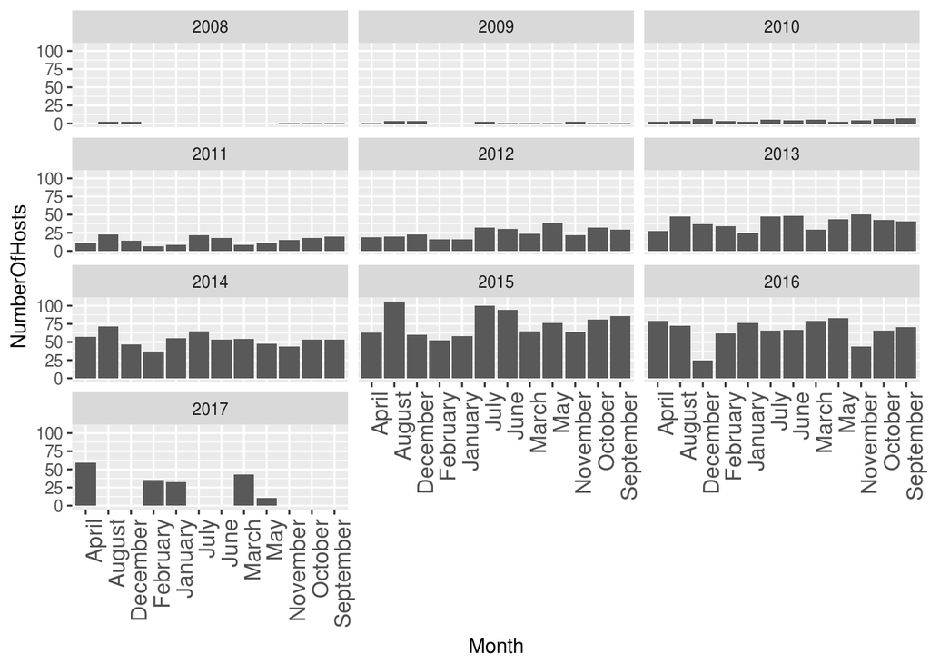

```r
tempHostCount<- dflistings %>% group_by(Year= as.numeric(format(dflistings$host_since,"%Y")), Month = format(dflistings$host_since,"%m")) %>% summarise(NumberOfHosts = length(unique(host_id)))

tempHostCount$Month <- month.name[as.numeric(tempHostCount$Month)]
ggplot(tempHostCount, aes(Month,NumberOfHosts)) +  geom_bar(stat='identity') +
    facet_wrap(~ Year,ncol=3) +theme(axis.text.x = element_text(angle = 90, hjust = 1,size =12))
```

## Anaysis by Time Factor

We tried to plot a graph of overal availability throught the time period available in the date set to check the busy time period for the available listings

It looks like until July the listings were pretty booked and availablity increased after the July 2017. The prices keeps on fluctuating day to day.

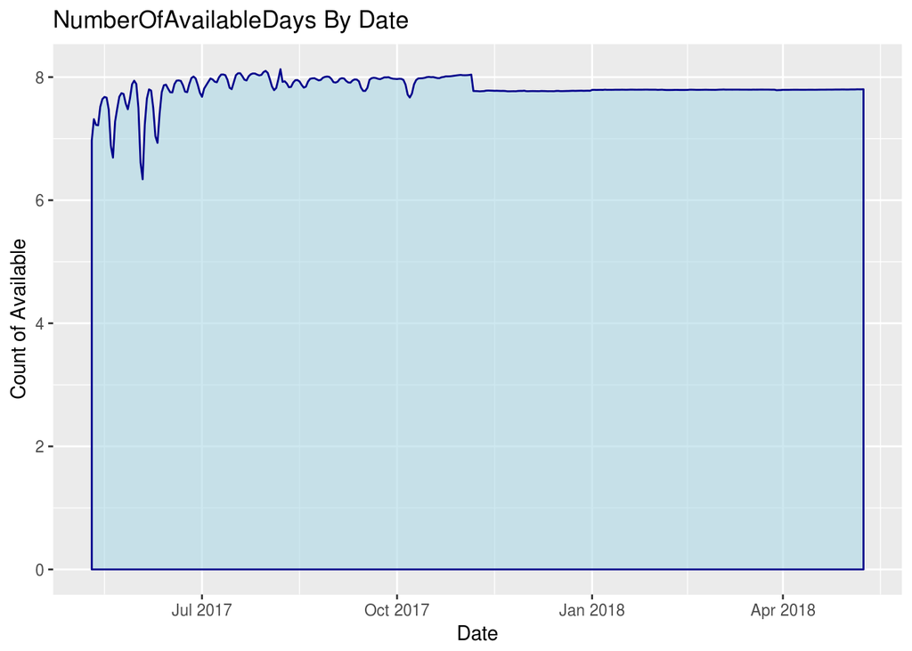

```r
tempdf <- dfCalendars%>% group_by(date)%>%
  filter(available == 't') %>% summarize(countavailable = n(), AveragePrice = mean(price))

ggplot(tempdf, aes(date, log(countavailable) )) +
  ggtitle("NumberOfAvailableDays By Date") +
  xlab("Date")+
  ylab("Count of Available") +
  geom_area(fill="lightblue",color="darkblue",alpha = 0.6)
```

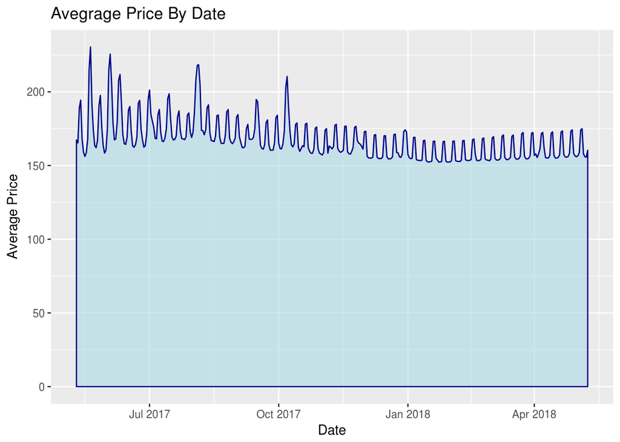

```r
ggplot(tempdf, aes(date, AveragePrice ))   +
    ggtitle("Avegrage Price By Date") +
  xlab("Date")+
  ylab("Average Price")+
    geom_area(fill="lightblue",color="darkblue",alpha = 0.6)
```

This chart might not be give a good idea about trend from 2017 to 2018 due incomplete data !!!! So, analysisng data over the months might help to get some insights

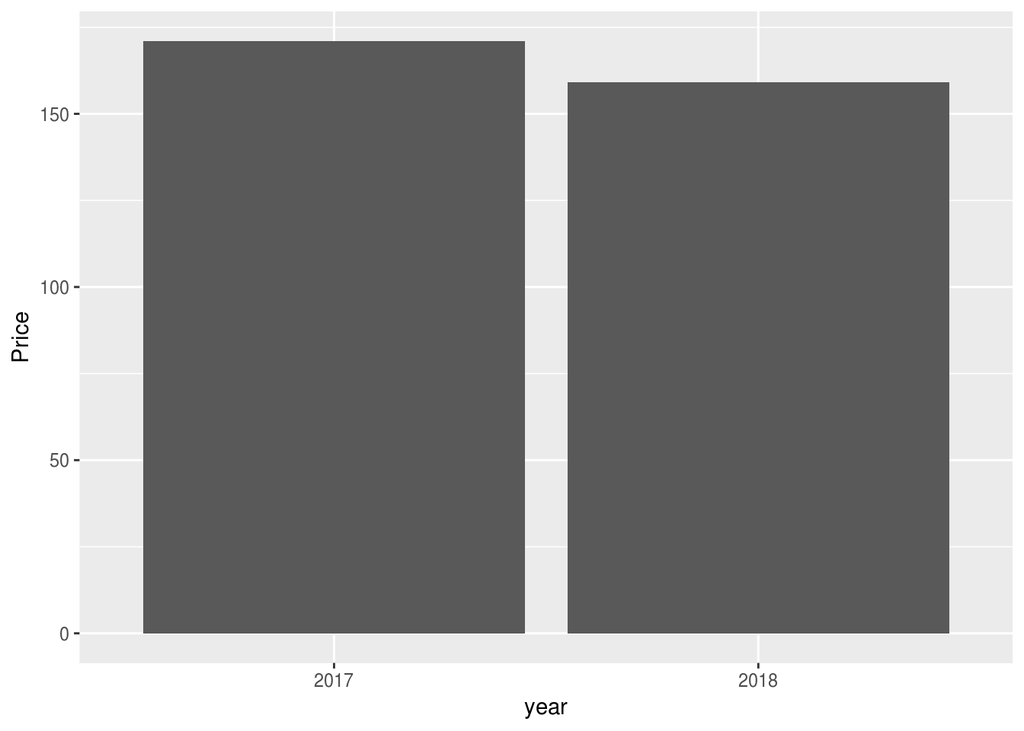

```r
tempdf <- dfCalendars%>% group_by(year)%>% filter(available == 't') %>% summarize(BookedDays = n(),Price = mean(price))

ggplot(tempdf, aes(year, Price)) + geom_bar(stat="identity")
```

Clearly, Chicago seems to be highly booked in the month of May , possiblity due to good weather ,The number of booked days are also high during December,this could be possibly due to winter vacations !!

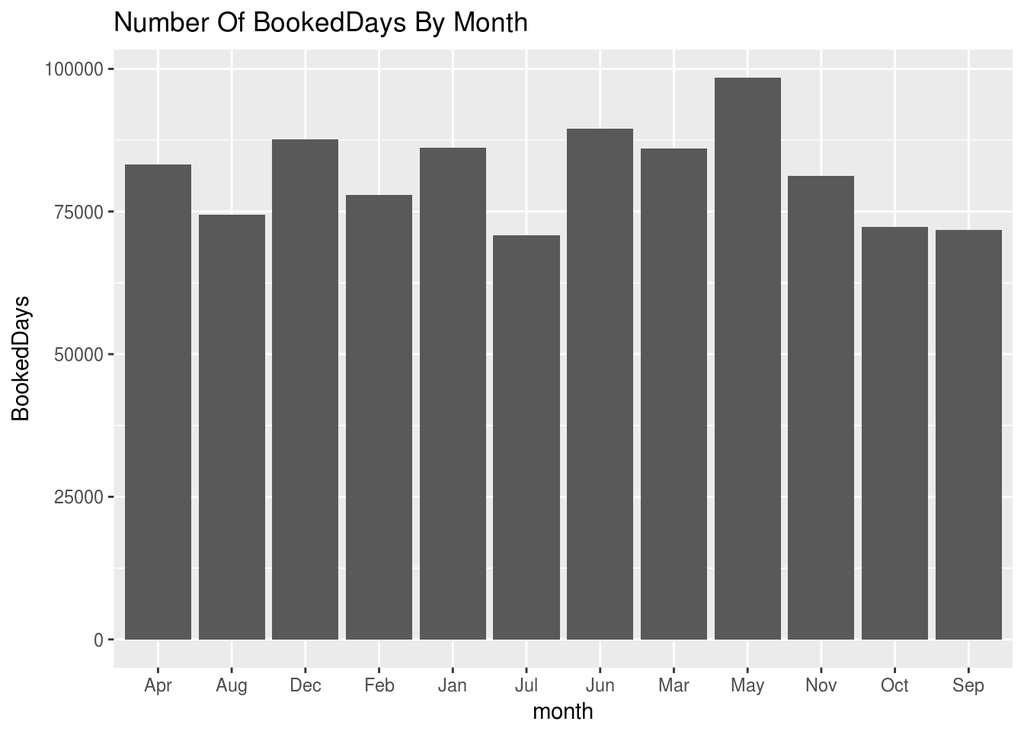

```r
tempdf <- dfCalendars%>% group_by(month)%>% filter(available == 'f') %>% summarize(BookedDays = n() )
ggplot(tempdf, aes(month, BookedDays)) + geom_bar(stat="identity") +
  ggtitle("Number Of BookedDays By Month")
```

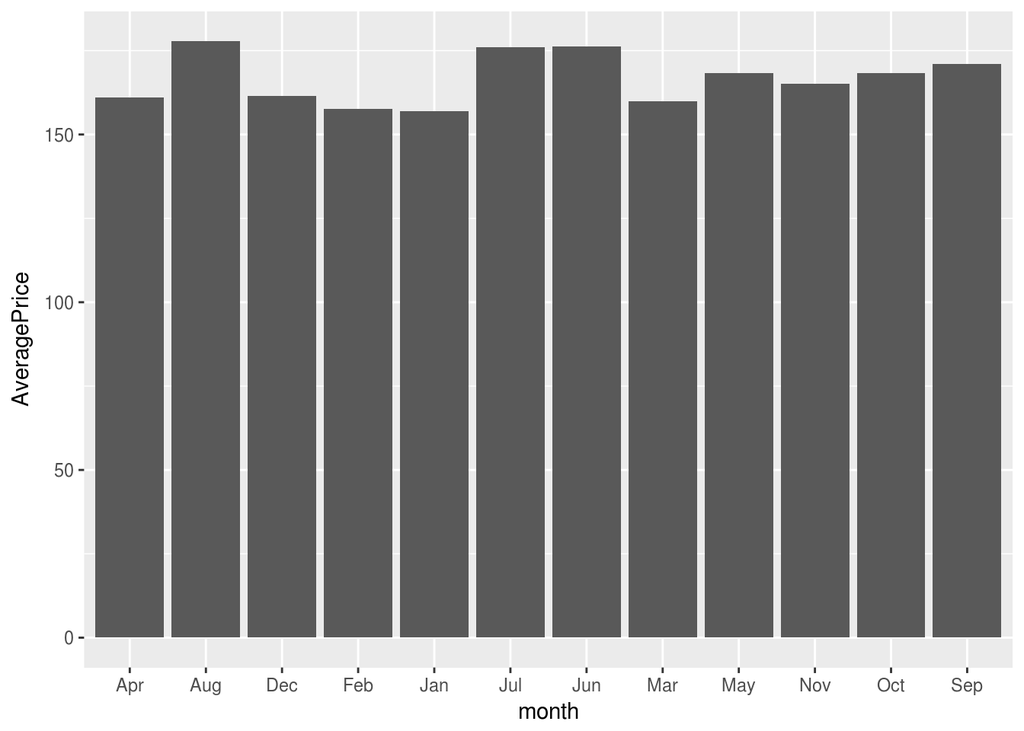

```r
tempdf <- dfCalendars%>% group_by(month)%>% filter(available == 't') %>% summarize(AveragePrice = mean(price) )
ggplot(tempdf, aes(month, AveragePrice)) + geom_bar(stat="identity")
```

```r
  ggtitle("Average Price By Month")
```

```
## $title
## [1] "Average Price By Month"
##
## $subtitle
## NULL
##
## attr(,"class")
## [1] "labels"
```

## What makes the Price Differ

Finally some EDA to find some relation between price and other variables

**1. Price and Neighbourhood** The price differs pretty much by neighbouhood,both the barchart and box plot explains this,in certain neighbourhood the average price is really high while others have low. The ditribution of price again differs with neigbourhood.

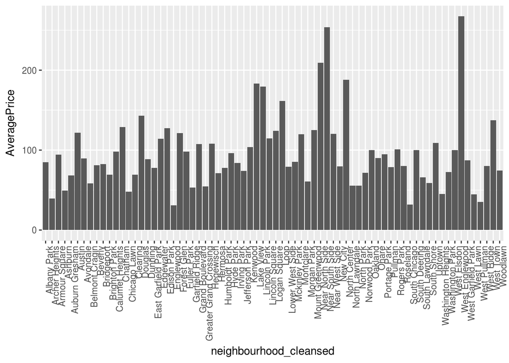

```r
tempdf <-dflistings%>% group_by(neighbourhood_cleansed) %>% summarise(AveragePrice = mean(price)) %>% arrange(desc(AveragePrice))


ggplot(tempdf, aes(neighbourhood_cleansed,AveragePrice )) + geom_bar(stat = 'identity') +
    theme(axis.text.x=element_text(angle=90,hjust=1))
```

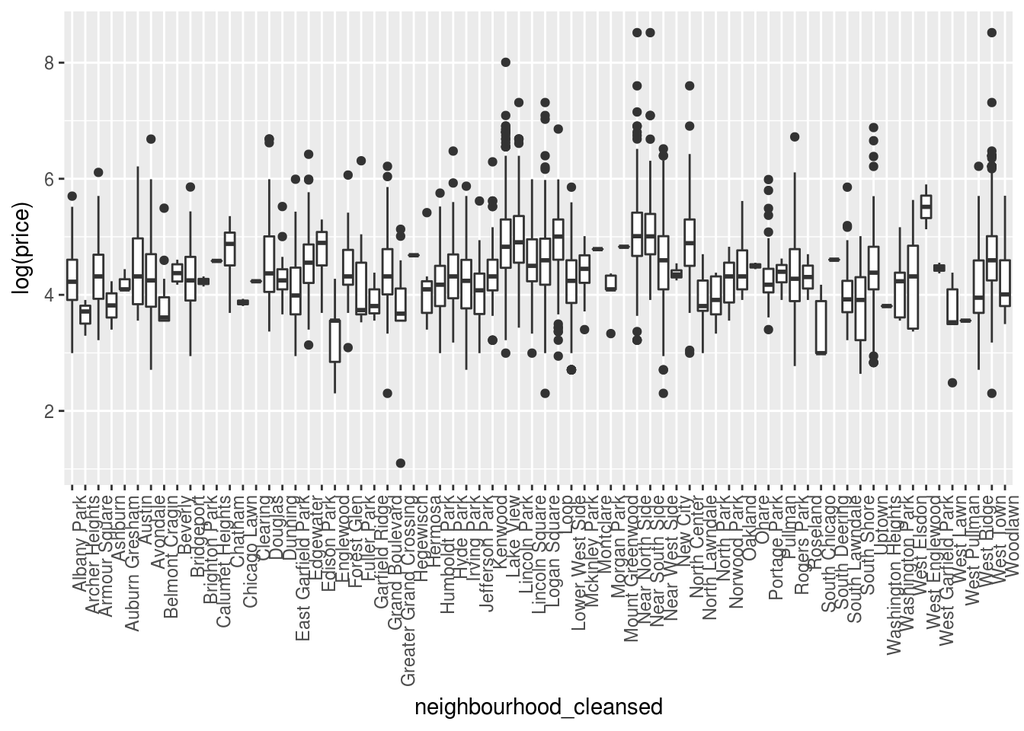

```r
ggplot(dflistings, aes(neighbourhood_cleansed, log(price) )) +  geom_boxplot() +
    theme(axis.text.x=element_text(angle=90,hjust=1))
```

**2.Number of Reviews vs Price for listings**

It could be seen that the listings with a price range of 0 to 500 gets the most number of reviews ,possibly that these are affordable places,and most prefered type on airbnb!!!!

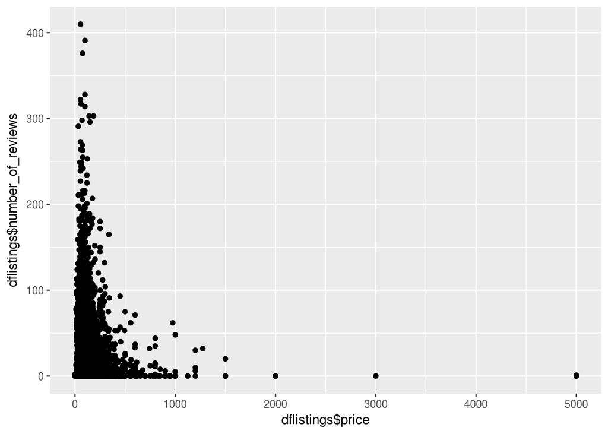

```r
ggplot(dflistings, aes(dflistings$price,dflistings$number_of_reviews)) +  geom_point()
```

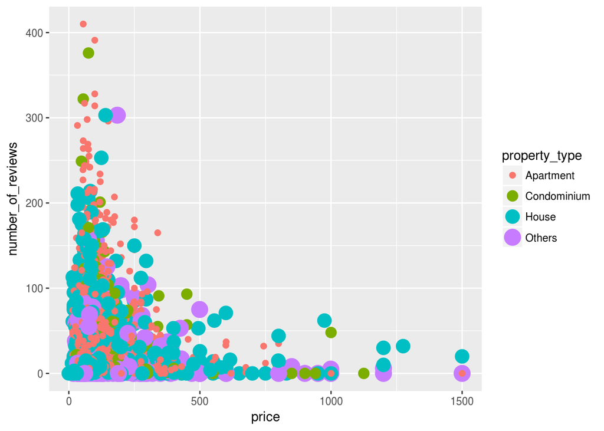

```r
tempdf <-dflistings %>%
  filter(dflistings$price < 2000)

ggplot(tempdf, aes(price,number_of_reviews,size = property_type,color= property_type)) +  geom_point()
```

**3.Instantly bookable vs Price**

There doesnt seem to be much difference with respect to Instantly bookable places ,although the price range for Instant bookalabe places is a little wide that those not!!

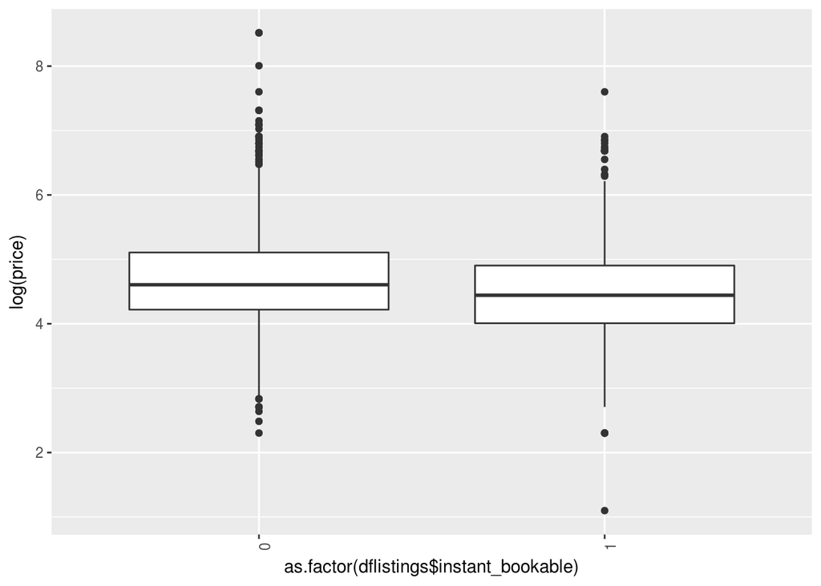

```r
ggplot(dflistings, aes( as.factor(dflistings$instant_bookable) , log(price) )) +  geom_boxplot() +
    theme(axis.text.x=element_text(angle=90,hjust=1))
```

**4.Cancellation Policy vs Price**

These again do not differ greatly price although ,the superstrict group seems to be pretty narrow in range while the flexible group seems to be pretty wide with range of price

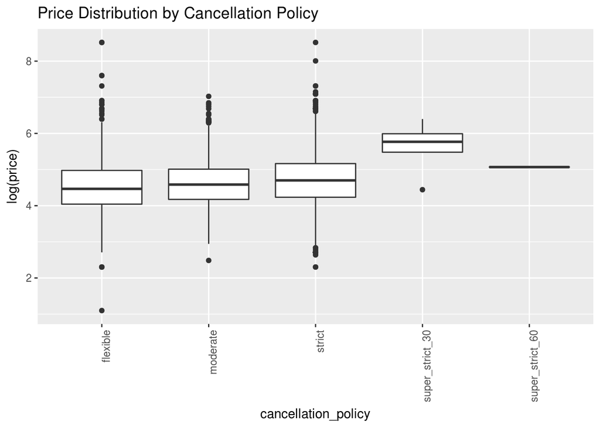

```r
ggplot(dflistings, aes( as.factor(dflistings$cancellation_policy) , log(price) )) +  geom_boxplot() +
    theme(axis.text.x=element_text(angle=90,hjust=1))  +
  ggtitle("Price Distribution by Cancellation Policy") +
  xlab("cancellation_policy")
```

```r
  ylab("Price")
```

```
## $y
## [1] "Price"
##
## attr(,"class")
## [1] "labels"
```

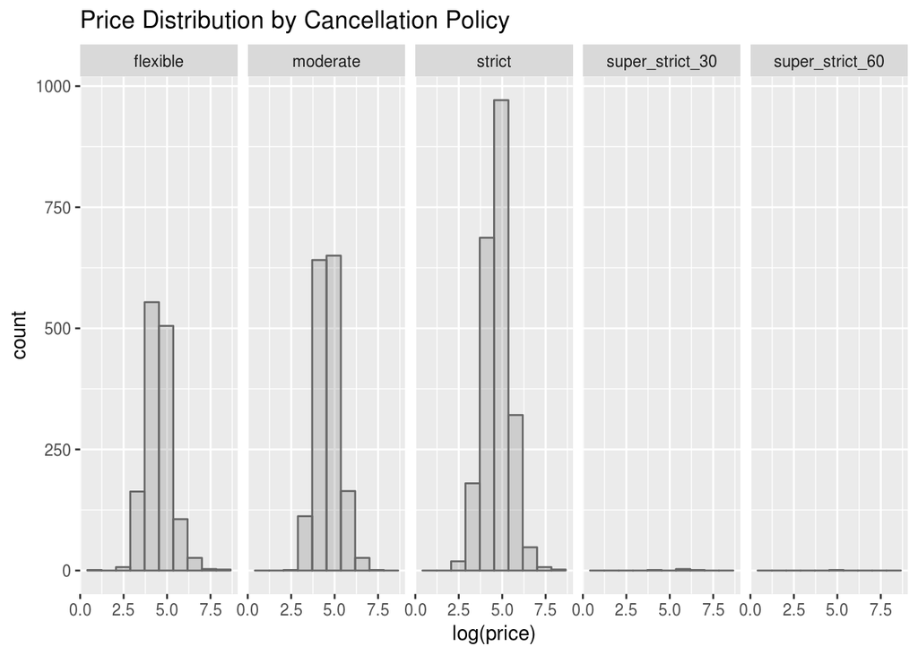

```r
ggplot(dflistings, aes(x=log(price),color = room_type)) +
    geom_histogram(position="identity", colour="grey40", alpha=0.2, bins = 10) +
  facet_grid(. ~ dflistings$cancellation_policy)+
 ggtitle("Price Distribution by Cancellation Policy")
```

**5.ActiveDays vs Price**

Calculated Field with first and Last Review i.e duration the Listing was active

The graph shows a leaflike structure,for listings with less number of active days,he price range is narrow and it widens with increased number of active days

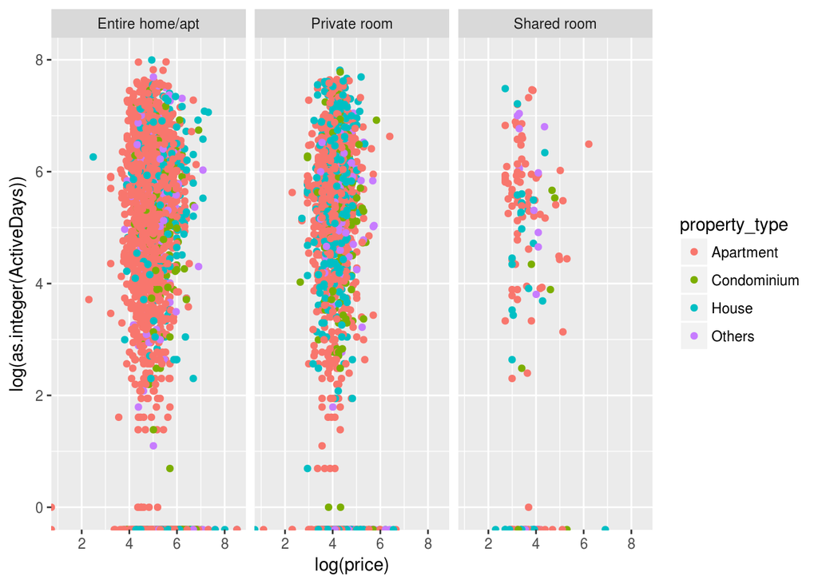

```r
dflistings$ActiveDays <- difftime(dflistings$last_review,dflistings$first_review, units = "days") # days
dflistings$ActiveDays[is.na(dflistings$ActiveDays)] <- 0

ggplot(dflistings, aes(log(price), log(as.integer(ActiveDays))  ,color = property_type)) +  geom_point() +
      facet_wrap(~ dflistings$room_type)
```

**6.Effect of Host being a SuperHost on Price and Reviews**

It could be seen that Superhost on an average have lower listing price,also they have higher number of reviews possibly popular amongst the airbnb users !!!

```r
dflistings %>%group_by(host_is_superhost)%>%summarize(PriceAverage = mean(price),Reviews= mean(number_of_reviews))
```

```
## # A tibble: 2 x 3
##   host_is_superhost PriceAverage Reviews
##               <int>        <dbl>   <dbl>
## 1                 0         140.    19.9
## 2                 1         125.    40.9
```

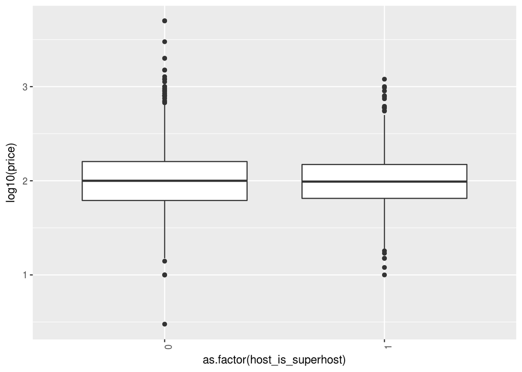

```r
ggplot(dflistings, aes( as.factor(host_is_superhost) , log10(price) )) +  geom_boxplot() +
    theme(axis.text.x=element_text(angle=90,hjust=1))
```

## Save the dataframe

```r
dflistings <- dflistings[ -c(1) ]
 dflistings[0]
```

```
## data frame with 0 columns and 5206 rows
```

```r
# Save Dataframe for regression
 saveRDS(dflistings, file="data.Rda")
```